# Analyze_ab_test_results_notebook

## Analyze A/B Test Results - e-commerce website

- Introduction
- Part I - Probability
- Part II - A/B Test
- Part III - Regression

### Introduction

For this project, we will be working to understand the results of an A/B test run by an e-commerce website. The goal is to work through this notebook to help the company understand if they should implement the new page, keep the old page, or perhaps run the experiment longer to make their decision.

#### Part I - Probability

To get started, let's import our libraries.

```python
import pandas as pd
import numpy as np
import random
import matplotlib.pyplot as plt
%matplotlib inline
#We are setting the seed to assure you get the same answers on quizzes as we set up
random.seed(42)
```

Explore `ab_data.csv` data.

```python
df = pd.read_csv('ab_data.csv')
df.head()
```

|  | user_id | timestamp | group | landing_page | converted |
| --- | --- | --- | --- | --- | --- |
| 0 | 851104 | 2017-01-21 22:11:48.556739 | control | old_page | 0 |
| 1 | 804228 | 2017-01-12 08:01:45.159739 | control | old_page | 0 |
| 2 | 661590 | 2017-01-11 16:55:06.154213 | treatment | new_page | 0 |
| 3 | 853541 | 2017-01-08 18:28:03.143765 | treatment | new_page | 0 |
| 4 | 864975 | 2017-01-21 01:52:26.210827 | control | old_page | 1 |

Find the number of rows in the dataset.

```python
no_of_rows = df.shape[0]
print('Total dataset rows: {}'.format(no_of_rows))
```

```
Total dataset rows: 294478
```

The number of unique users in the dataset.

```python
unique_users = df['user_id'].nunique()
print('Unique users is: {}'.format(unique_users))
```

```
Unique users is: 290584
```

The proportion of users converted.

```python
converted_propotion  = df['converted'].mean()
print('Proportion of users converted is: {}'.format(converted_propotion))
```

```
Proportion of users converted is: 0.11965919355605512
```

The number of times the `new_page` and `treatment` don't line up.

```python
#group is control and landing page is new_page
control_newpg = df.query("group == 'control' and landing_page == 'new_page'")
# group is treatment and landing page oldpage
treatment_oldpg = df.query("group == 'treatment' and landing_page == 'old_page'")
total = treatment_oldpg['user_id'].count()+control_newpg['user_id'].count()

print('The number of times the new_page and treatment don\'t line up is: {}'.format(total))
```

```
The number of times the new_page and treatment don't line up is: 3893
```

Do any of the rows have missing values?

```python
df.isnull().sum()
```

```
user_id         0
timestamp       0
group           0
landing_page    0
converted       0
dtype: int64
```

For the rows where **treatment** is not aligned with **new_page** or **control** is not aligned with **old_page**, we cannot be sure if this row truly received the new or old page. We will drop the rows that below and create a new dataset **df2**.

```python
df.drop(control_newpg.index, inplace=True)
df.drop(treatment_oldpg.index, inplace=True)

df.info()
df2 = df
```

```
<class 'pandas.core.frame.DataFrame'>
Int64Index: 290585 entries, 0 to 294477
Data columns (total 5 columns):
user_id         290585 non-null int64
timestamp       290585 non-null object
group           290585 non-null object
landing_page    290585 non-null object
converted       290585 non-null int64
dtypes: int64(2), object(3)
memory usage: 13.3+ MB
```

```python
# Double Check all of the correct rows were removed - this should be 0
df2[((df2['group'] == 'treatment') == (df2['landing_page'] == 'new_page')) == False].shape[0]
```

```
0
```

Using df2 dataset:

Calculate number of unique users

```python
df2['user_id'].nunique()
```

```
290584
```

Which user is duplicated?

```python
df2[df2['user_id'].duplicated(keep=False)]['user_id']
```

```
1899    773192
2893    773192
Name: user_id, dtype: int64
```

What is the row information for the repeat **user_id**?

```python
df2[df2['user_id'].duplicated(keep=False)]
```

|  | user_id | timestamp | group | landing_page | converted |
| --- | --- | --- | --- | --- | --- |
| 1899 | 773192 | 2017-01-09 05:37:58.781806 | treatment | new_page | 0 |
| 2893 | 773192 | 2017-01-14 02:55:59.590927 | treatment | new_page | 0 |

Remove rows with a duplicate **user_id**

```python
df2 = df2[df2.timestamp != '2017-01-09 05:37:58.781806']
```

```python
df2.info()
```

```
<class 'pandas.core.frame.DataFrame'>
Int64Index: 290584 entries, 0 to 294477
Data columns (total 5 columns):
user_id         290584 non-null int64
timestamp       290584 non-null object
group           290584 non-null object
landing_page    290584 non-null object
converted       290584 non-null int64
dtypes: int64(2), object(3)
memory usage: 13.3+ MB
```

What is the probability of an individual converting regardless of the page they receive?

```python
df['converted'].mean()
```

```
0.11959667567149027
```

Given that an individual was in the `control` group, what is the probability they converted?

```python
df[df['group'] == 'control']['converted'].mean()
```

```
0.1203863045004612
```

Given that an individual was in the `treatment` group, what is the probability they converted?

```python
df[df['group'] == 'treatment']['converted'].mean()
```

```
0.11880724790277405
```

What is the probability that an individual received the new page?

```python
new_page_users = df[df['landing_page'] == 'new_page']['user_id'].count()
new_page_users/unique_users
```

```
0.5000653855683727
```

**Using results from above analysis is there sufficient evidence to say that the new treatment page leads to more conversions?**

The old page has a slightly higher conversion than the new page. This may be attributed by factors such as small experiment duration or change aversion

### Part II - A/B Test

Assuming that the old page is better unless the new page proves to be definitely better at a Type I error rate of 5%, the null and alternative hypotheses will be:

$H_{0}$ : $p_{new}$ <= $p_{old}$

$H_{1}$ : $p_{new}$ > $p_{old}$

Assume under the null hypothesis, $p_{new}$ and $p_{old}$ both have "true" success rates equal to the **converted** success rate regardless of page - that is $p_{new}$ and $p_{old}$ are equal. Furthermore, assume they are equal to the **converted** rate in **ab_data.csv** regardless of the page.

We ll use a sample size for each page equal to the ones in **ab_data.csv**.

Then perform the sampling distribution for the difference in **converted** between the two pages over 10,000 iterations of calculating an estimate from the null.

What is the **convert rate** for $p_{new}$ under the null?

```python
converted_new = df2['converted'].mean()
converted_new
```

```
0.11959708724499628
```

What is the **convert rate** for $p_{old}$ under the null?

```python
converted_old = df2['converted'].mean()
converted_old
```

```
0.11959708724499628
```

What is $n_{new}$?

```python
total_new = df2.query("group == 'treatment'")['user_id'].count()
total_new
```

```
145310
```

What is $n_{old}$?

```python
total_old = df2.query("group == 'control'")['user_id'].count()
total_old
```

```
145274
```

Simulate $n_{new}$ transactions with a convert rate of $p_{new}$ under the null. Store these $n_{new}$ 1's and 0's in **new_page_converted**.

```python
new_page_converted = np.random.choice([1, 0], size=total_new, p=[converted_new, (1-converted_new)])
```

Simulate $n_{old}$ transactions with a convert rate of $p_{old}$ under the null. Store these $n_{old}$ 1's and 0's in **old_page_converted**.

```python
old_page_converted = np.random.choice([1, 0], size=total_old, p=[converted_old, (1-converted_old)])
```

Find $p_{new}$ - $p_{old}$ for your simulated values

```python
#ensure arrays are of same size
new_page_converted = new_page_converted[:len(old_page_converted)]
diff = (new_page_converted/total_new)-(old_page_converted/total_old)
```

```python
diffs = []

for _ in range(10000):
    new_page_converted = np.random.choice([1, 0], size=total_new, p=[converted_new, (1-converted_new)])
    old_page_converted = np.random.choice([1, 0], size=total_old, p=[converted_old, (1-converted_old)])

    new_page_converted_mean = new_page_converted.mean()
    old_page_converted_mean = old_page_converted.mean()

    diffs.append(new_page_converted_mean - old_page_converted_mean)
```

Plot a histogram of the **p_diffs**.

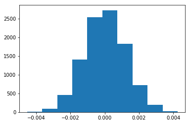

```python
plt.hist(diffs);
```

What proportion of the **p_diffs** are greater than the actual difference observed in **ab_data.csv**?

```python
mean_diff = df[df['group'] == 'treatment']['converted'].mean() -  df[df['group'] == 'control']['converted'].mean()
mean_diff
```

```
-0.0015790565976871451
```

```python
#calculating the p value
diffs = np.array(diffs)
(mean_diff < diffs).mean()
```

```
0.9051
```

calculate the number of conversions for each page, as well as the number of individuals who received each page. Let `n_old` and `n_new` refer the the number of rows associated with the old page and new pages, respectively.

```python
import statsmodels.api as sm

convert_old = sum(df2.query("group == 'control'")['converted'])
convert_new = sum(df2.query("group == 'treatment'")['converted'])
n_old = df2.query("group == 'control'")['user_id'].count()
n_new = df2.query("group == 'treatment'")['user_id'].count()
```

Using `stats.proportions_ztest` to compute test statistic and p-value.

```python
zscore, pvalue = sm.stats.proportions_ztest([convert_old, convert_new], [n_old, n_new], alternative='smaller')
print(zscore, pvalue)
```

```
1.3109241984234394 0.9050583127590245
```

```python
from scipy.stats import norm

print(norm.cdf(zscore))
print(norm.ppf(1-(0.05)))
```

```
0.9050583127590245
1.6448536269514722
```

### Part III - A regression approach

In this part, we aim to achieve the same results of the A/B test by performing Logistic regression.

The goal is to use **statsmodels** to fit the logistic regression model to see if there is a significant difference in conversion based on which page a customer receives.

Create a column for the intercept, and create a dummy variable column for which page each user received. Add an **intercept** column, as well as an **ab_page** column, which is 1 when an individual receives the **treatment** and 0 if **control**.

```python
import statsmodels.api as sm
df['intercept']=1
df[['control', 'treatment']] = pd.get_dummies(df['group'])
```

```python
lg = sm.Logit(df['converted'],df[['intercept','treatment']])
```

Model summary below;

```python
lg.fit().summary()
```

```
Optimization terminated successfully.
         Current function value: 0.366118
         Iterations 6
```

Logit Regression Results

| Dep. Variable: | converted | No. Observations: | 290585 |
| --- | --- | --- | --- |
| Model: | Logit | Df Residuals: | 290583 |
| Method: | MLE | Df Model: | 1 |
| Date: | Tue, 27 Aug 2019 | Pseudo R-squ.: | 8.085e-06 |
| Time: | 11:39:11 | Log-Likelihood: | -1.0639e+05 |
| converged: | True | LL-Null: | -1.0639e+05 |
|  |  | LLR p-value: | 0.1897 |

|  | coef | std err | z | P>\|z\| | [0.025 | 0.975] |
| --- | --- | --- | --- | --- | --- | --- |
| intercept | -1.9888 | 0.008 | -246.669 | 0.000 | -2.005 | -1.973 |
| treatment | -0.0150 | 0.011 | -1.312 | 0.190 | -0.037 | 0.007 |

What is the p-value associated with **ab_page**? Why does it differ from the value you found in the AB Test results?

p-value 0.190

The A/B Test results part takes into account a hypothesis of one of the variables whereas in this part the hypothesis involves the difference in the two variables to show relationship hence the smaller p-value

**Logistic regression Hypothesis:**

$H_{0}$ : $p_{new}$ - $p_{old}$ = 0

$H_{1}$ : $p_{new}$ - $p_{old}$ != 0

In the logistic regression we assume there is no relationship between the pages and conversion rate. In part II as below we assume the old page has a more conversion rate than the new page.

**Part II hypothesis**

$H_{0}$ : $p_{new}$ <= $p_{old}$

$H_{1}$ : $p_{new}$ > $p_{old}$

**Is it a good idea to consider other factors to add into your regression model?**

**Are there any disadvantages to adding additional terms into your regression model?**

It is important to include other factors such as change aversion as they have an impact in the conversions. There are more advantages than disadvantages of additional terms. The more the terms the more accuracy in the model, however as much as we include these factors some of them remain theoretical in the final decision.

Lets add an effect based on which country a user lives.

**Does it appear that country had an impact on conversion?**

```python
countries_df = pd.read_csv('./countries.csv')
df_new = countries_df.set_index('user_id').join(df.set_index('user_id'), how='inner')
```

```python
### Create the necessary dummy variables
df_new[['CA', 'UK', 'US']] = pd.get_dummies(df_new['country'])
df_new.head()
```

| user_id | country | timestamp | group | landing_page | converted | intercept | control | treatment | CA | UK | US |
| --- | --- | --- | --- | --- | --- | --- | --- | --- | --- | --- | --- |
| 630000 | US | 2017-01-19 06:26:06.548941 | treatment | new_page | 0 | 1 | 0 | 1 | 0 | 0 | 1 |
| 630001 | US | 2017-01-16 03:16:42.560309 | treatment | new_page | 1 | 1 | 0 | 1 | 0 | 0 | 1 |
| 630002 | US | 2017-01-19 19:20:56.438330 | control | old_page | 0 | 1 | 1 | 0 | 0 | 0 | 1 |
| 630003 | US | 2017-01-12 10:09:31.510471 | treatment | new_page | 0 | 1 | 0 | 1 | 0 | 0 | 1 |
| 630004 | US | 2017-01-18 20:23:58.824994 | treatment | new_page | 0 | 1 | 0 | 1 | 0 | 0 | 1 |

```python
### Fit Your Linear Model And Obtain the Results
df_new['intercept'] = 1
lg = sm.Logit(df_new['converted'],df_new[['intercept', 'treatment', 'US', 'UK']])
lg.fit().summary()
```

```
Optimization terminated successfully.
         Current function value: 0.366112
         Iterations 6
```

Logit Regression Results

| Dep. Variable: | converted | No. Observations: | 290585 |
| --- | --- | --- | --- |
| Model: | Logit | Df Residuals: | 290581 |
| Method: | MLE | Df Model: | 3 |
| Date: | Tue, 27 Aug 2019 | Pseudo R-squ.: | 2.324e-05 |
| Time: | 12:02:01 | Log-Likelihood: | -1.0639e+05 |
| converged: | True | LL-Null: | -1.0639e+05 |
|  |  | LLR p-value: | 0.1758 |

|  | coef | std err | z | P>\|z\| | [0.025 | 0.975] |
| --- | --- | --- | --- | --- | --- | --- |
| intercept | -2.0300 | 0.027 | -76.249 | 0.000 | -2.082 | -1.978 |
| treatment | -0.0150 | 0.011 | -1.308 | 0.191 | -0.037 | 0.007 |
| US | 0.0408 | 0.027 | 1.516 | 0.130 | -0.012 | 0.093 |
| UK | 0.0506 | 0.028 | 1.784 | 0.074 | -0.005 | 0.106 |

```python
np.exp(lg.fit().params)
```

```
Optimization terminated successfully.
         Current function value: 0.366112
         Iterations 6
```

```
intercept    0.131332
treatment    0.985160
US           1.041593
UK           1.051944
dtype: float64
```

```python
df.groupby('group').mean()['converted']
```

```
group
control      0.120386
treatment    0.118807
Name: converted, dtype: float64
```

CA(Canada) is the baseline as it is left out in the regression model with US users being 1.04 times likely to convert as Canadians users and UK users being 1.05 times likely to convert as Canadian users. The p-values are large hence statistically insignificant.

looking at an interaction between page and country to see if there significant effects on conversion.

```python
# These columns indicate that a given user received both the new page
#    and lived in the country shown.
df_new['T_CA'] = df_new['treatment']*df_new['CA']
df_new['T_UK'] = df_new['treatment']*df_new['UK']
df_new['T_US'] = df_new['treatment']*df_new['US']
```

```python
df_new.head()
```

| user_id | country | timestamp | group | landing_page | converted | intercept | control | treatment | CA | UK | US | T_CA | T_UK | T_US |
| --- | --- | --- | --- | --- | --- | --- | --- | --- | --- | --- | --- | --- | --- | --- |
| 630000 | US | 2017-01-19 06:26:06.548941 | treatment | new_page | 0 | 1 | 0 | 1 | 0 | 0 | 1 | 0 | 0 | 1 |
| 630001 | US | 2017-01-16 03:16:42.560309 | treatment | new_page | 1 | 1 | 0 | 1 | 0 | 0 | 1 | 0 | 0 | 1 |
| 630002 | US | 2017-01-19 19:20:56.438330 | control | old_page | 0 | 1 | 1 | 0 | 0 | 0 | 1 | 0 | 0 | 0 |
| 630003 | US | 2017-01-12 10:09:31.510471 | treatment | new_page | 0 | 1 | 0 | 1 | 0 | 0 | 1 | 0 | 0 | 1 |
| 630004 | US | 2017-01-18 20:23:58.824994 | treatment | new_page | 0 | 1 | 0 | 1 | 0 | 0 | 1 | 0 | 0 | 1 |

```python
### Fit Your Linear Model And Obtain the Results
lm = sm.OLS(df_new['converted'],df_new[['intercept','treatment','US','T_US','UK','T_UK']])
results = lm.fit()
results.summary()
```

OLS Regression Results

| Dep. Variable: | converted | R-squared: | 0.000 |
| --- | --- | --- | --- |
| Model: | OLS | Adj. R-squared: | 0.000 |
| Method: | Least Squares | F-statistic: | 1.467 |
| Date: | Tue, 27 Aug 2019 | Prob (F-statistic): | 0.197 |
| Time: | 12:03:01 | Log-Likelihood: | -85264. |
| No. Observations: | 290585 | AIC: | 1.705e+05 |
| Df Residuals: | 290579 | BIC: | 1.706e+05 |
| Df Model: | 5 |  |  |
| Covariance Type: | nonrobust |  |  |

|  | coef | std err | t | P>\|t\| | [0.025 | 0.975] |
| --- | --- | --- | --- | --- | --- | --- |
| intercept | 0.1188 | 0.004 | 31.057 | 0.000 | 0.111 | 0.126 |
| treatment | -0.0069 | 0.005 | -1.277 | 0.202 | -0.017 | 0.004 |
| US | 0.0018 | 0.004 | 0.467 | 0.641 | -0.006 | 0.010 |
| T_US | 0.0047 | 0.006 | 0.845 | 0.398 | -0.006 | 0.016 |
| UK | 0.0012 | 0.004 | 0.296 | 0.767 | -0.007 | 0.009 |
| T_UK | 0.0080 | 0.006 | 1.360 | 0.174 | -0.004 | 0.020 |

| Omnibus: | 125550.316 | Durbin-Watson: | 2.000 |
| --- | --- | --- | --- |
| Prob(Omnibus): | 0.000 | Jarque-Bera (JB): | 414291.118 |
| Skew: | 2.345 | Prob(JB): | 0.00 |
| Kurtosis: | 6.497 | Cond. No. | 26.1 |

Warnings:  
[1] Standard Errors assume that the covariance matrix of the errors is correctly specified.

```python
lg = sm.Logit(df_new['converted'],df_new[['intercept','treatment','US','T_US','UK','T_UK']])
results = lg.fit()
results.summary()
```

```
Optimization terminated successfully.
         Current function value: 0.366108
         Iterations 6
```

Logit Regression Results

| Dep. Variable: | converted | No. Observations: | 290585 |
| --- | --- | --- | --- |
| Model: | Logit | Df Residuals: | 290579 |
| Method: | MLE | Df Model: | 5 |
| Date: | Tue, 27 Aug 2019 | Pseudo R-squ.: | 3.483e-05 |
| Time: | 12:03:08 | Log-Likelihood: | -1.0639e+05 |
| converged: | True | LL-Null: | -1.0639e+05 |
|  |  | LLR p-value: | 0.1918 |

|  | coef | std err | z | P>\|z\| | [0.025 | 0.975] |
| --- | --- | --- | --- | --- | --- | --- |
| intercept | -2.0040 | 0.036 | -55.008 | 0.000 | -2.075 | -1.933 |
| treatment | -0.0674 | 0.052 | -1.297 | 0.195 | -0.169 | 0.034 |
| US | 0.0175 | 0.038 | 0.465 | 0.642 | -0.056 | 0.091 |
| T_US | 0.0469 | 0.054 | 0.872 | 0.383 | -0.059 | 0.152 |
| UK | 0.0118 | 0.040 | 0.296 | 0.767 | -0.066 | 0.090 |
| T_UK | 0.0783 | 0.057 | 1.378 | 0.168 | -0.033 | 0.190 |

```python
print(np.exp(0.0408), np.exp(0.0506))
print(np.exp(0.0175), np.exp(0.0118))
```

```
1.0416437559600236 1.0519020483004984
1.0176540221507617 1.011869894648401
```

The above 2 are linear and logistic regressions. In the linear regression R-squared is 0 meaning a bad fit. Both results have high p-values hence statistically insignificant.

Due to the small difference (0.01) between countries there is no difference in how page influences conversion from one country to the other